# ¿Dónde conviene comprar confitería?

Comparador de precios en Éxito, Carulla y Jumbo

Carlos Ernesto Araujo Romero · Universidad Nacional de Colombia

06/11/2026

Taller Parcial 1 · Minería de Datos · Universidad Nacional de Colombia

# ¿Dónde conviene comprar confitería?

Comparador de precios en Éxito, Carulla y Jumbo

Carlos Ernesto Araujo Romero · Precios capturados el 06/11/2026 a las 19:38 (hora Colombia) · 3 ejecuciones en 2 fechas

La respuesta corta: no hay una sola tienda ganadora. Te mostramos qué comprar en cada una, cuánto puedes ahorrar y cuándo la presentación grande sí vale la pena.

13

presentaciones comparadas

3

comercios

39

precios comparables

34,6%

ahorro máximo

**La idea en una frase.** No hay un solo almacén que sea el más barato para toda la confitería. La diferencia cambia producto por producto; conviene revisar la tabla antes de decidir y separar el ahorro por unidad del desembolso total.

## Lo que encontramos

🏆

### El podio se reparte

**Jumbo (5) · Carulla (4) · Éxito (4)**. Ningún comercio gana en todo; la mejor decisión depende del producto y de la presentación.

🧺

### La canasta completa

Comprar las 13 presentaciones en un solo lugar cuesta entre **$187.410** y **$192.874**. La opción más barata es **Jumbo**.

📦

### Grande no siempre es mejor

En Corona, la barra de 200 g de Éxito es más eficiente por 100 g que la de 450 g. En Millows, la de 300 g sí gana en los tres comercios.

## La guía de compra

Esta es la tabla que responde la pregunta central: **¿dónde comprar cada producto?** Está ordenada de mayor a menor ahorro potencial. La columna “Más barato en” ya tiene en cuenta los empates.

Canasta comparable: dónde está más barata cada presentación y cuánto se ahorra.

| Producto | Subcategoría | Más barato en | Precio más bajo | Precio más alto | Ahorro |
| --- | --- | --- | --- | --- | --- |
| Gomitas Vidal ojos sangrientos 90 g | Gomitas y masmelos | Jumbo | $5.890 | $9.000 | $3.110 (34,6%) |
| Gomitas Trululu gusanos ácidos 100 g | Gomitas y masmelos | Carulla | $3.440 | $4.590 | $1.150 (25,1%) |
| Dulces Nerds uva fresa 46 g | Caramelos | Jumbo | $9.190 | $12.100 | $2.910 (24,0%) |
| Gomitas Trululu aros surtidos 300 g | Gomitas y masmelos | Carulla | $10.500 | $13.390 | $2.890 (21,6%) |
| Chocolate Corona tradicional 200 g | Chocolates | Éxito | $7.144 | $8.290 | $1.146 (13,8%) |
| Chocolate Lindt 70% cacao 100 g | Chocolates | Jumbo | $45.290 | $50.700 | $5.410 (10,7%) |
| Caramelos Tic Tac fruit adventure 16 g | Mentas | Carulla | $2.600 | $2.880 | $280 (9,7%) |
| Masmelos Millows 75 g | Gomitas y masmelos | Éxito | $3.410 | $3.690 | $280 (7,6%) |
| Ferrero Rocher corazón 100 g | Chocolates | Carulla | $37.650 | $40.490 | $2.840 (7,0%) |
| Gomitas Haribo gusanos 80 g | Gomitas y masmelos | Éxito | $9.060 | $9.600 | $540 (5,6%) |
| Chocolate Milka con leche 80 g | Chocolates | Jumbo | $17.690 | $18.300 | $610 (3,3%) |
| Masmelos Millows 300 g | Gomitas y masmelos | Éxito | $10.600 | $10.950 | $350 (3,2%) |
| Chocolate Corona tradicional 450 g | Chocolates | Jumbo | $16.390 | $16.700 | $310 (1,9%) |

Precios de venta observados el 06/11/2026. No incluyen domicilio, mínimos de compra, cupones, programas de fidelización ni precios de tienda física.

**Si quieres una sola compra.** La canasta completa más económica en un solo almacén es **Jumbo**, con **$187.410**. Si puedes combinar comercios, el costo baja a **$178.854**.

## 1. ¿Con qué datos contamos?

**Respuesta corta.** Trabajamos con 3 comercios, 13 presentaciones idénticas y 39 precios comparables. El catálogo completo de la categoría suma 5.879 observaciones dentro de la delimitación.

Conteos generales de la ejecución.

| Comercios | Observaciones | Comercios con datos | Observaciones comparables | Productos comparables |
| --- | --- | --- | --- | --- |
| 3 | 5.879 | 3 | 39 | 13 |

Aporte de cada comercio a la base.

| Comercio | Observaciones | Comparables | Subcategorías |
| --- | --- | --- | --- |
| Éxito | 3.026 | 13 | 5 |
| Carulla | 2.344 | 13 | 5 |
| Jumbo | 509 | 13 | 5 |

Éxito: 3.026 observaciones · Carulla: 2.344 observaciones · Jumbo: 509 observaciones. La canasta comparable está balanceada: 13 presentaciones × 3 comercios = 39 precios.

## 2. ¿La comparación es justa?

**Respuesta corta.** Sí. Cada producto se comparó contra la misma marca, la misma variante, el mismo contenido y la misma unidad. No se mezclaron tamaños ni presentaciones distintas.

Cobertura de la canasta comparable en la ejecución.

| Productos comparables | Con 3 comercios | Observaciones comparables | Mínimo de comercios | Máximo de comercios |
| --- | --- | --- | --- | --- |
| 13 | 13 | 39 | 3 | 3 |

Registros repetidos del mismo SKU en la ejecución.

| Duplicados |
| --- |
| 0 |

**Calidad de la canasta.** Las 39 observaciones comparables tienen precio, marca, contenido y URL. No hay faltantes que afecten la comparación y no hay SKUs duplicados en la ejecución.

**Ver la correspondencia exacta de las 13 presentaciones**

El mismo producto/presentación, con el nombre original de cada comercio.

| Producto | Éxito | Carulla | Jumbo |
| --- | --- | --- | --- |
| Caramelos Tic Tac fruit adventure 16 g | Caramelos TIC TAC fruit adventure (16 gr) | Caramelos TIC TAC fruit adventure (16 gr) | Pastilla Fruit Adventure Tic Tac x16grs |
| Chocolate Corona tradicional 200 g | Chocolate CORONA tradicional (200 gr) | Chocolate CORONA tradicional (200 gr) | Chocolate Corona Tradicional x8 Und x200grs |
| Chocolate Corona tradicional 450 g | Chocolate CORONA tradicional pastillado (450 gr) | Chocolate CORONA tradicional pastillado (450 gr) | Chocolate Corona Tradicional x18 Und x450grs |
| Chocolate Lindt 70% cacao 100 g | Chocolates LINDT amargo 70% cocoa (100 gr) | Chocolates LINDT amargo 70% cocoa (100 gr) | tableta Chocolate lindt excellence 70% cocoa x 100 g |
| Chocolate Milka con leche 80 g | Barra de chocolate MILKA chocolate con leche (80 gr) | Barra de chocolate MILKA chocolate con leche (80 gr) | Chocolate Milka Leche x80g |
| Dulces Nerds uva fresa 46 g | Dulces NERDS sabor uva fresa (46 gr) | Dulces NERDS sabor uva fresa (46 gr) | Caramelo Nerds Candy Uva Fresa 46g |
| Ferrero Rocher corazón 100 g | Chocolates FERRERO ROCHER de corazón chocolate y avellana (100 gr) | Chocolates FERRERO ROCHER de corazón chocolate y avellana (100 gr) | Estuche Corazón Ferrero Rocher x100grs |
| Gomitas Haribo gusanos 80 g | Gomitas HARIBO gusanos sabor a frutas (80 gr) | Gomitas HARIBO gusanos sabor a frutas (80 gr) | Gomitas Haribo gusanos x80g |
| Gomitas Trululu aros surtidos 300 g | Gomitas TRULULU aros surtidos (300 gr) | Gomitas TRULULU aros surtidos (300 gr) | Gomas Trululu aros x 300g |
| Gomitas Trululu gusanos ácidos 100 g | Gomitas TRULULU gusanos ácidos (100 gr) | Gomitas TRULULU gusanos ácidos (100 gr) | Gomas Trululu Gusanos Acidos 100g |
| Gomitas Vidal ojos sangrientos 90 g | Gomitas VIDAL ojos sangrientos (90 gr) | Gomitas VIDAL ojos sangrientos (90 gr) | Gomas Vidal ojos sangrientos x90g |
| Masmelos Millows 300 g | MASMELOS ORIGINAL MILLOWS 300 gr | MASMELOS ORIGINAL MILLOWS 300 gr | Masmelos original natural Millows x 300g |
| Masmelos Millows 75 g | Masmelos MILLOWS 75 gr | Masmelos MILLOWS 75 gr | Masmelos Millows x 75g |

## 3. ¿Dónde está más barato cada producto?

**Respuesta corta.** El más barato cambia producto por producto. En esta ejecución, Jumbo (5) · Carulla (4) · Éxito (4). No hay empates.

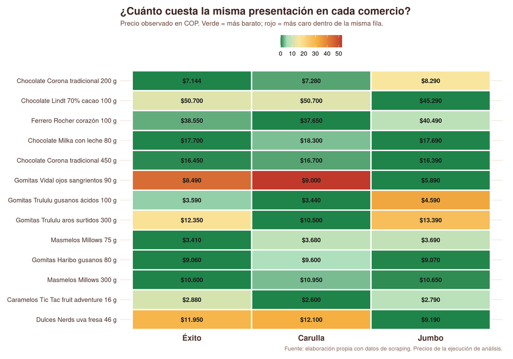

Precio de cada presentación comparable en los tres comercios. El color indica el porcentaje sobre el precio más barato de esa fila.

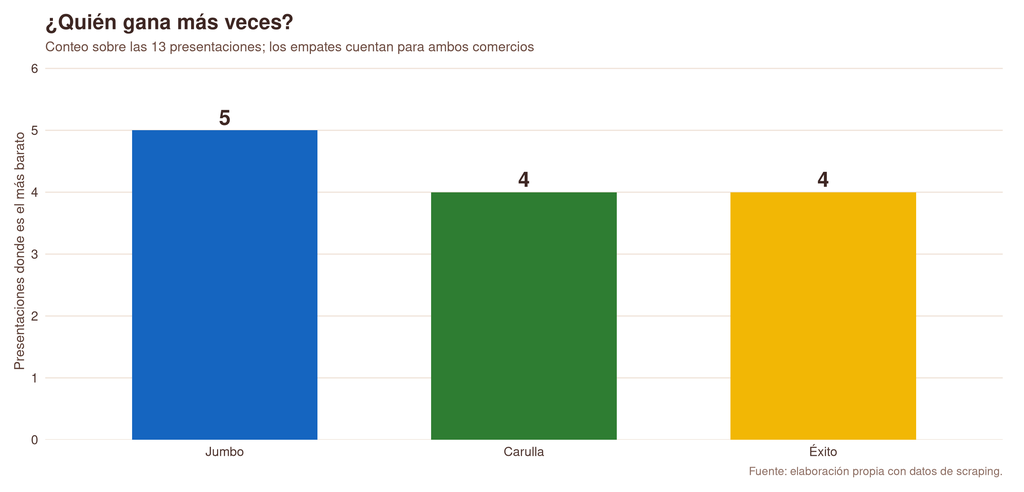

Número de presentaciones en las que cada comercio es el más barato. Los empates, si existen, cuentan para ambos comercios.

Precios extremos y comercio más barato; los empates se listan juntos.

| Producto | Precio mínimo | Precio máximo | Precio promedio | Más barato en |
| --- | --- | --- | --- | --- |
| Chocolate Corona tradicional 200 g | $7.144 | $8.290 | $7.571 | Éxito |
| Chocolate Corona tradicional 450 g | $16.390 | $16.700 | $16.513 | Jumbo |
| Chocolate Milka con leche 80 g | $17.690 | $18.300 | $17.897 | Jumbo |
| Chocolate Lindt 70% cacao 100 g | $45.290 | $50.700 | $48.897 | Jumbo |
| Ferrero Rocher corazón 100 g | $37.650 | $40.490 | $38.897 | Carulla |
| Gomitas Trululu gusanos ácidos 100 g | $3.440 | $4.590 | $3.873 | Carulla |
| Gomitas Trululu aros surtidos 300 g | $10.500 | $13.390 | $12.080 | Carulla |
| Gomitas Haribo gusanos 80 g | $9.060 | $9.600 | $9.243 | Éxito |
| Masmelos Millows 75 g | $3.410 | $3.690 | $3.593 | Éxito |
| Masmelos Millows 300 g | $10.600 | $10.950 | $10.733 | Éxito |
| Caramelos Tic Tac fruit adventure 16 g | $2.600 | $2.880 | $2.757 | Carulla |
| Gomitas Vidal ojos sangrientos 90 g | $5.890 | $9.000 | $7.793 | Jumbo |
| Dulces Nerds uva fresa 46 g | $9.190 | $12.100 | $11.080 | Jumbo |

**Cómo leer el mapa.** Cada fila es una presentación; cada columna, un comercio. El verde marca el precio más bajo de esa fila y el rojo, el más alto. La etiqueta muestra el precio en pesos. Así se ve de un vistazo dónde conviene comprar cada producto, sin promediar surtidos distintos.

## 4. ¿Cuánto ahorro si cambio de comercio?

**Respuesta corta.** El ahorro relativo va de **1,9%** a **34,6%**. El mayor ahorro en pesos está en **Chocolate Lindt 70% cacao 100 g**: **$5.410**.

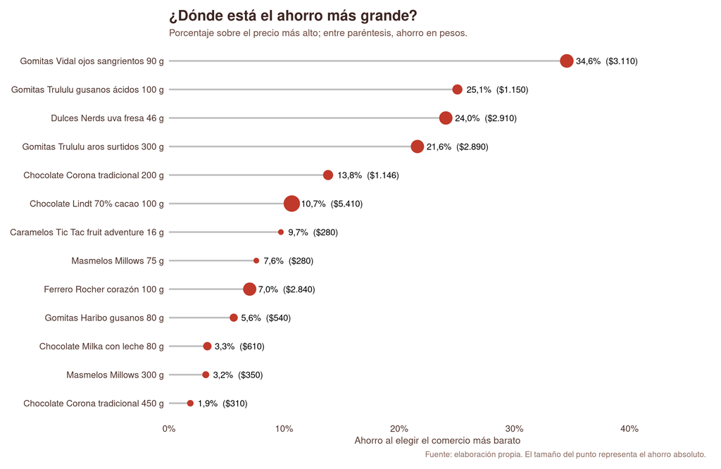

Ahorro porcentual y en pesos al elegir la oferta más económica de cada presentación.

Ahorro potencial al elegir la oferta más económica de cada presentación.

| Producto | Precio mínimo | Precio máximo | Ahorro COP | Ahorro % |
| --- | --- | --- | --- | --- |
| Gomitas Vidal ojos sangrientos 90 g | $5.890 | $9.000 | $3.110 | 34,6% |
| Gomitas Trululu gusanos ácidos 100 g | $3.440 | $4.590 | $1.150 | 25,1% |
| Dulces Nerds uva fresa 46 g | $9.190 | $12.100 | $2.910 | 24,0% |
| Gomitas Trululu aros surtidos 300 g | $10.500 | $13.390 | $2.890 | 21,6% |
| Chocolate Corona tradicional 200 g | $7.144 | $8.290 | $1.146 | 13,8% |
| Chocolate Lindt 70% cacao 100 g | $45.290 | $50.700 | $5.410 | 10,7% |
| Caramelos Tic Tac fruit adventure 16 g | $2.600 | $2.880 | $280 | 9,7% |
| Masmelos Millows 75 g | $3.410 | $3.690 | $280 | 7,6% |
| Ferrero Rocher corazón 100 g | $37.650 | $40.490 | $2.840 | 7,0% |
| Gomitas Haribo gusanos 80 g | $9.060 | $9.600 | $540 | 5,6% |
| Chocolate Milka con leche 80 g | $17.690 | $18.300 | $610 | 3,3% |
| Masmelos Millows 300 g | $10.600 | $10.950 | $350 | 3,2% |
| Chocolate Corona tradicional 450 g | $16.390 | $16.700 | $310 | 1,9% |

**Lectura.** La mayor brecha relativa está en **Gomitas Vidal ojos sangrientos 90 g** (34,6%, $3.110). La mayor brecha absoluta está en **Chocolate Lindt 70% cacao 100 g** ($5.410). Son dos formas distintas de mirar el mismo ahorro: porcentaje para comparar productos de distinto precio, pesos para saber cuánto entra en el bolsillo.

Precios promocionales detectados: el precio de venta es menor al precio de lista.

| Producto | Comercio | Precio de venta | Precio de lista | Descuento |
| --- | --- | --- | --- | --- |
| Chocolate Corona tradicional 200 g | Éxito | $7.144 | $8.930 | 20,0% |
| Chocolate Corona tradicional 200 g | Carulla | $7.280 | $9.100 | 20,0% |

**Ojo con las promociones.** El precio comparado es el de venta. Si la promoción termina, el ranking de esas presentaciones puede cambiar.

## 5. ¿La presentación grande conviene?

**Respuesta corta.** No siempre. En Corona tradicional, la barra de 200 g de Éxito es la más eficiente por 100 g; la de 450 g no mejora ese indicador en Éxito ni en Carulla. En Millows original, la de 300 g sí es más eficiente que la de 75 g en los tres comercios.

Precio por 100 g en las dos familias con más de una presentación comparable.

| Producto | Presentación | Comercio | Precio | COP por 100 g | Ranking |
| --- | --- | --- | --- | --- | --- |
| Corona tradicional | 200 g | Éxito | $7.144 | $3.572 | 1 |
| Corona tradicional | 200 g | Carulla | $7.280 | $3.640 | 2 |
| Corona tradicional | 450 g | Jumbo | $16.390 | $3.642 | 3 |
| Corona tradicional | 450 g | Éxito | $16.450 | $3.656 | 4 |
| Corona tradicional | 450 g | Carulla | $16.700 | $3.711 | 5 |
| Corona tradicional | 200 g | Jumbo | $8.290 | $4.145 | 6 |
| Millows original | 300 g | Éxito | $10.600 | $3.533 | 1 |
| Millows original | 300 g | Jumbo | $10.650 | $3.550 | 2 |
| Millows original | 300 g | Carulla | $10.950 | $3.650 | 3 |
| Millows original | 75 g | Éxito | $3.410 | $4.547 | 4 |
| Millows original | 75 g | Carulla | $3.680 | $4.907 | 5 |
| Millows original | 75 g | Jumbo | $3.690 | $4.920 | 6 |

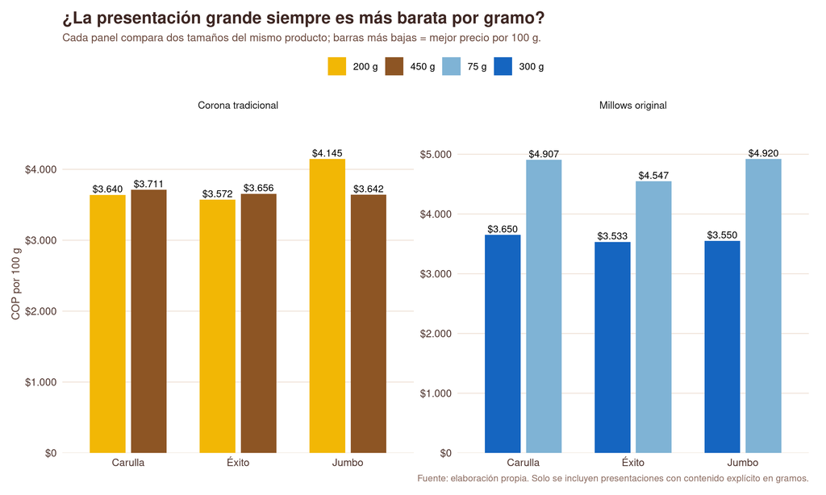

Precio por 100 g en las dos familias con dos presentaciones comparables: Corona tradicional y Millows original.

**Lectura.** La presentación grande suele reducir el precio por gramo, pero no de forma automática. Hay que mirar el **precio por 100 g** y no solo el tamaño del empaque. Además, la presentación grande exige más dinero en la caja: una cosa es el ahorro unitario y otra el desembolso total.

## 6. ¿Dónde están las mayores diferencias?

**Respuesta corta.** La mayor diferencia absoluta está en **Chocolate Lindt 70% cacao 100 g** ($5.410); la mayor diferencia relativa, en **Gomitas Vidal ojos sangrientos 90 g** (34,6%).

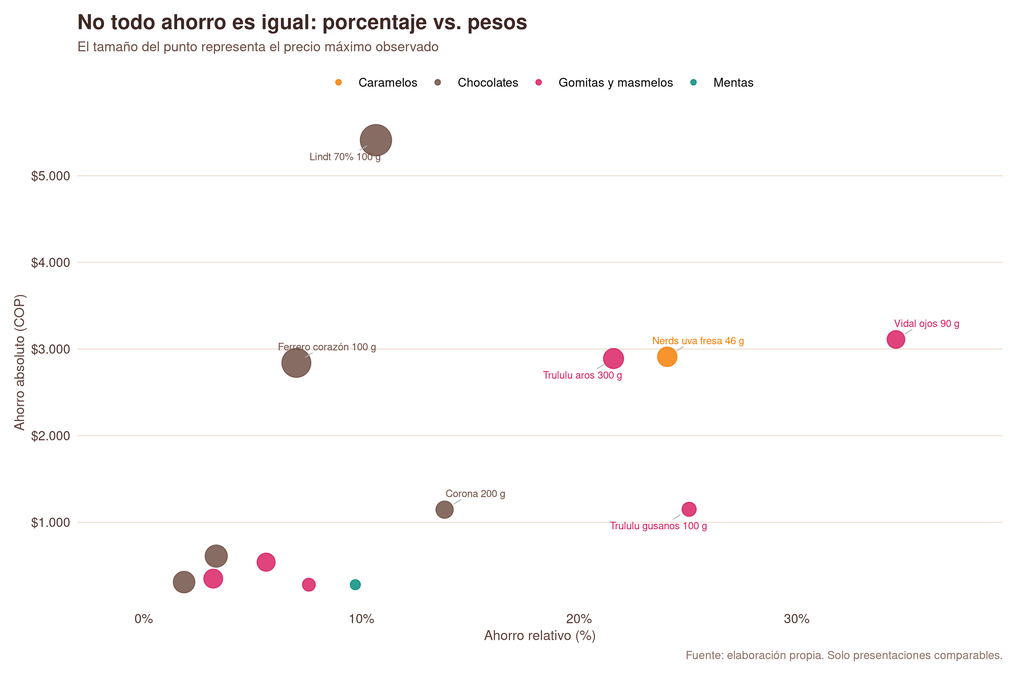

Relación entre el ahorro relativo y el ahorro absoluto. El tamaño del punto representa el precio máximo observado; el color, la subcategoría.

Ranking por diferencia absoluta entre el precio máximo y el mínimo.

| Producto | Diferencia COP | Diferencia % | Precio mínimo | Precio máximo |
| --- | --- | --- | --- | --- |
| Chocolate Lindt 70% cacao 100 g | $5.410 | 10,7% | $45.290 | $50.700 |
| Gomitas Vidal ojos sangrientos 90 g | $3.110 | 34,6% | $5.890 | $9.000 |
| Dulces Nerds uva fresa 46 g | $2.910 | 24,0% | $9.190 | $12.100 |
| Gomitas Trululu aros surtidos 300 g | $2.890 | 21,6% | $10.500 | $13.390 |
| Ferrero Rocher corazón 100 g | $2.840 | 7,0% | $37.650 | $40.490 |
| Gomitas Trululu gusanos ácidos 100 g | $1.150 | 25,1% | $3.440 | $4.590 |
| Chocolate Corona tradicional 200 g | $1.146 | 13,8% | $7.144 | $8.290 |
| Chocolate Milka con leche 80 g | $610 | 3,3% | $17.690 | $18.300 |
| Gomitas Haribo gusanos 80 g | $540 | 5,6% | $9.060 | $9.600 |
| Masmelos Millows 300 g | $350 | 3,2% | $10.600 | $10.950 |
| Chocolate Corona tradicional 450 g | $310 | 1,9% | $16.390 | $16.700 |
| Masmelos Millows 75 g | $280 | 7,6% | $3.410 | $3.690 |
| Caramelos Tic Tac fruit adventure 16 g | $280 | 9,7% | $2.600 | $2.880 |

**Lectura.** El tamaño del punto representa el precio máximo: los productos caros pueden tener un ahorro absoluto alto aunque su porcentaje no sea el mayor. Ordenar por pesos y ordenar por porcentaje cuenta dos historias complementarias.

## 7. ¿Hay datos que falten?

**Respuesta corta.** En la canasta comparable, **cero**. Las 39 observaciones tienen precio, marca, contenido y URL. En el catálogo completo sí hay ausencias: 4.117 productos sin precio y 287 sin contenido identificable en el nombre.

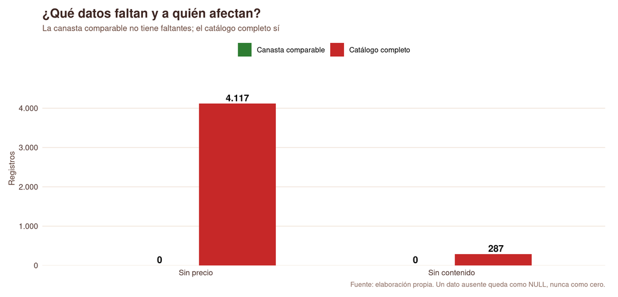

Faltantes de precio y contenido en la canasta comparable y en el catálogo completo de la ejecución.

Faltantes en el catálogo completo de la ejecución.

| Total | Sin precio | Sin contenido | Sin marca | Sin descripción | Sin URL |
| --- | --- | --- | --- | --- | --- |
| 5.879 | 4.117 | 287 | 0 | 0 | 0 |

Faltantes en la canasta comparable: no debería haber ninguno.

| Total | Sin precio | Sin contenido | Sin marca | Sin URL |
| --- | --- | --- | --- | --- |
| 39 | 0 | 0 | 0 | 0 |

**Lectura.** Las ausencias del catálogo completo no afectan la comparación de las 13 presentaciones: la canasta se armó solo con productos que tenían precio y contenido en los tres comercios. No se imputó ningún precio ni contenido; un dato ausente quedó como ausente, no como cero.

## 8. ¿Qué tan grande es la oferta?

**Respuesta corta.** Éxito y Carulla tienen catálogos más amplios, pero solo una parte tiene precio disponible. Jumbo tiene menos productos, pero casi todos están disponibles.

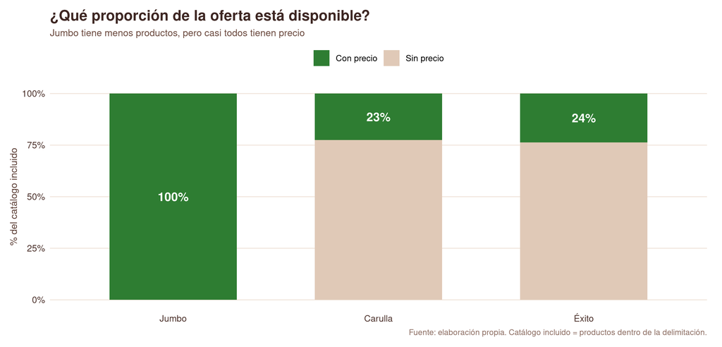

Proporción del catálogo incluido que tiene precio disponible en cada comercio.

Tamaño de la oferta y calidad de los atributos por comercio.

[output not shown]

**Lectura.** El tamaño del catálogo no es lo mismo que la oferta disponible. Éxito y Carulla publican miles de productos, pero una fracción importante está agotada o sin precio en línea. Jumbo publica menos, pero su tasa de disponibilidad es casi total. La comparación de precios se hizo solo con productos disponibles en los tres comercios.

## 9. ¿Y si compro todo en un solo lugar?

**Respuesta corta.** Comprar las 13 presentaciones en un solo almacén cuesta entre **$187.410** y **$192.874**. La opción más barata es **Jumbo** con **$187.410**.

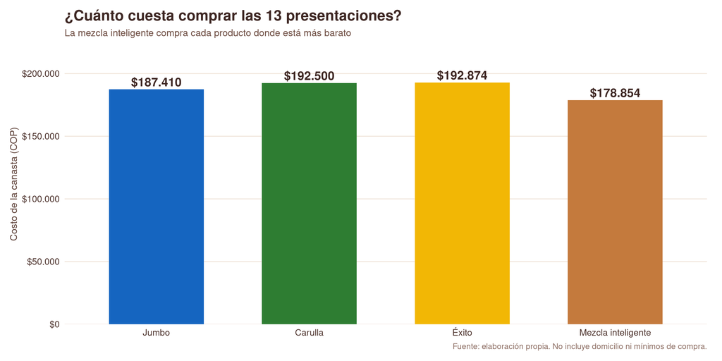

Costo de las 13 presentaciones compradas en un solo comercio y costo de la mezcla inteligente.

Costo de las mismas presentaciones compradas en un solo comercio.

| Comercio | Productos con precio | Costo de la canasta |
| --- | --- | --- |
| Jumbo | 13 | $187.410 |
| Carulla | 13 | $192.500 |
| Éxito | 13 | $192.874 |

**Lectura.** La mezcla inteligente —comprar cada producto donde está más barato— cuesta **$178.854**: un ahorro de **$14.020** (7,3%) frente a la canasta más costosa. Pero exige visitar varios comercios o pagar varios domicilios. Si el envío cuesta más que el ahorro, conviene comprar todo en un solo lugar.

## 10. ¿Cambiaron los precios entre fechas?

**Respuesta corta.** La comparación principal usa la ejecución más reciente (06/11/2026). La base conserva 3 ejecuciones completas en 2 fechas. Entre la corrida anterior y esta se detectaron 1 cambio de precio.

Cambios de precio entre la ejecución anterior y la más reciente (se muestran los 12 de mayor magnitud).

| Producto | Comercio | Antes | Ahora | Cambio |
| --- | --- | --- | --- | --- |
| Masmelos Millows 300 g | Éxito | $10.650 | $10.600 | -$50 (-0,5%) |

**Lectura.** Los cambios son la diferencia entre la captura anterior y la más reciente. La comparación principal no mezcla fechas: usa solo la ejecución más reciente.

## Cómo se hizo

1

### Elegimos la categoría

Confitería empacada: chocolates, caramelos, gomitas, chicles y mentas. Excluimos suplementos, pastillas para la garganta, café, cocoa y artículos de fiesta.

2

### Rastreamos la categoría completa

7.635 productos extraídos en las ramas equivalentes de los tres comercios; 5.879 quedaron dentro de la delimitación.

3

### Comparamos lo mismo

13 presentaciones con la misma marca, variante, contenido y unidad. La correspondencia se revisó una por una contra el texto original de cada sitio.

4

### Revisamos y repetimos

3 ejecuciones completas en 2 fechas, verificaciones de duplicados y una prueba de reprocesamiento sin conexión. El resultado offline fue idéntico.

Grupo Éxito

### Éxito

**3.026** productos en la categoría; **23,7%** con precio disponible.

Grupo Éxito

### Carulla

**2.344** productos en la categoría; **22,6%** con precio disponible.

Cencosud

### Jumbo

**509** productos en la categoría; **100,0%** con precio disponible.

**Qué quedó por fuera.** Se descartaron 1.756 registros: 1.295 de café u otras categorías que aparecen en ramas mixtas, 301 que no eran chocolate, 109 de fiesta o decoración, 37 de Halls, 5 suplementos y 9 bebidas en polvo. Todos los descartes conservan su motivo y su texto original.

**3 ejecuciones en 2 fechas.** La base conserva las corridas del 05/11 y del 06/11. La comparación usa la más reciente; las anteriores se conservan para medir cambios.

## Limitaciones

### Una foto, no una película

Los precios corresponden al momento de la captura. No son permanentes y pueden cambiar por promociones o ajustes de inventario.

### Sin costos de envío

No se incluyen domicilio, mínimos de compra, cupones, fidelización ni precios de tienda física. El ahorro puede desaparecer si el envío cuesta más.

### Promociones puntuales

Dos precios de la canasta son promocionales. Si la promoción termina, el ranking de esas presentaciones puede cambiar.

### Disponibilidad cambiante

Un producto publicado puede agotarse. La comparación usa solo productos con precio disponible en los tres comercios.

### La categoría se delimitó a mano

Cada sitio organiza la confitería a su manera. La equivalencia de ramas y las exclusiones están documentadas y son auditables.

### Datos de dos fechas

La comparación usa la ejecución del 06/11/2026; las corridas del 05/11 se conservan para medir cambios, no como una serie continua.

## Reproducibilidad

El informe se regenera abriendo **taller_1.Rmd** en RStudio y presionando **Knit**. La base comparador_precios.sqlite y las copias crudas raw/ ya están incluidas, así que no se necesita internet para compilarlo. Para una recolección nueva se usa scraper.R; para verificar sin conexión, verificacion_offline.R. Las versiones de los paquetes están fijadas en renv.lock.

| Archivo | Para qué sirve |
| --- | --- |
| taller_1.Rmd | Genera este informe. |
| styles.css | Estilos visuales de la presentación. |
| consultas.sql | Las ocho consultas SQL para revisión técnica. |
| comparador_precios.sqlite | Base con las 3 ejecuciones y las observaciones comparables de cada una. |
| raw/ | Copias crudas comprimidas de las respuestas de los tres comercios. |
| scraper.R | Módulo de extracción, carga a SQLite y modo offline. |
| mapeo_productos.csv | Correspondencia manual entre el SKU de cada comercio y el producto canónico. |
| docs/categorias.md | Delimitación de la categoría y equivalencias por comercio. |
| verificacion_offline.txt | Resultado de la prueba de reprocesamiento sin red. |
| renv.lock | Versiones fijas de los paquetes. |

**Verificación offline.** La reconstrucción desde las copias crudas produjo exactamente 5.879 observaciones, 39 observaciones comparables y 13 productos, idénticos a la base incluida. La comparación por comercio también coincidió en conteos, suma de precios y disponibilidad.

Fuente: elaboración propia con datos de scraping de Éxito, Carulla y Jumbo. Precios del 06/11/2026; no son permanentes. Este informe no es una recomendación nutricional ni terapéutica.